# Atividade Integradora 1 Trimestre

2023-09-06

# Lendo os dados

```r
df <- read.csv("data_2012.csv")

head(skim(df))
```

Data summary

| Name | df |
| --- | --- |
| Number of rows | 20952 |
| Number of columns | 47 |
| _______________________ |  |
| Column type frequency: |  |
| character | 2 |
| numeric | 4 |
| ________________________ |  |
| Group variables | None |

**Variable type: character**

| skim_variable | n_missing | complete_rate | min | max | empty | n_unique | whitespace |
| --- | --- | --- | --- | --- | --- | --- | --- |
| gender | 0 | 1 | 3 | 6 | 0 | 3 | 0 |
| origin | 0 | 1 | 3 | 8 | 0 | 3 | 0 |

**Variable type: numeric**

| skim_variable | n_missing | complete_rate | mean | sd | p0 | p25 | p50 | p75 | p100 | hist |
| --- | --- | --- | --- | --- | --- | --- | --- | --- | --- | --- |
| curr_assets | 0 | 1 | 98232.33 | 460057.4 | 0 | 3222.22 | 11081.48 | 38140.74 | 20663500 | ▇▁▁▁▁ |
| curr_liab | 0 | 1 | 86702.49 | 515361.5 | 0 | 3625.93 | 14159.26 | 46351.85 | 41864292 | ▇▁▁▁▁ |
| extra_exp | 0 | 1 | 1237.73 | 117959.6 | 0 | 0.00 | 0.00 | 0.00 | 17041718 | ▇▁▁▁▁ |
| extra_inc | 0 | 1 | 2408.58 | 122242.7 | 0 | 0.00 | 0.00 | 0.00 | 17092322 | ▇▁▁▁▁ |

```r
head(summary(df))
```

```
##   curr_assets         curr_liab          extra_exp          extra_inc
##  Min.   :       0   Min.   :       0   Min.   :       0   Min.   :       0
##  1st Qu.:    3222   1st Qu.:    3626   1st Qu.:       0   1st Qu.:       0
##  Median :   11081   Median :   14159   Median :       0   Median :       0
##  Mean   :   98232   Mean   :   86702   Mean   :    1238   Mean   :    2409
##  3rd Qu.:   38141   3rd Qu.:   46352   3rd Qu.:       0   3rd Qu.:       0
##  Max.   :20663500   Max.   :41864292   Max.   :17041718   Max.   :17092322
##  extra_profit_loss  fixed_assets        inc_bef_tax        intang_assets
##  Min.   :-248448   Min.   :        0   Min.   :-10918793   Min.   :      0
##  1st Qu.:      0   1st Qu.:       58   1st Qu.:    -6478   1st Qu.:      0
##  Median :      0   Median :     4259   Median :      204   Median :      0
##  Mean   :   1168   Mean   :   147533   Mean   :     5575   Mean   :   3702
##  3rd Qu.:      0   3rd Qu.:    36889   3rd Qu.:     3852   3rd Qu.:      0
##  Max.   :3253704   Max.   :103667280   Max.   :  4378226   Max.   :5630704
##   inventories         liq_assets       material_exp      personnel_exp
##  Min.   :       0   Min.   :      0   Min.   :       0   Min.   :      0
##  1st Qu.:       0   1st Qu.:    407   1st Qu.:    9841   1st Qu.:   3988
##  Median :    1115   Median :   1911   Median :   31161   Median :  10948
##  Mean   :   25418   Mean   :  24225   Mean   :  163229   Mean   :  52276
##  3rd Qu.:    6844   3rd Qu.:   8659   3rd Qu.:   94430   3rd Qu.:  29266
##  Max.   :17258574   Max.   :7687870   Max.   :14127548   Max.   :7945804
##  profit_loss_year       share_eq         subscribed_cap      tang_assets
##  Min.   :-10918793   Min.   :-10798185   Min.   :       0   Min.   :        0
##  1st Qu.:    -6485   1st Qu.:    -8374   1st Qu.:    1852   1st Qu.:        0
##  Median :       19   Median :     3367   Median :    1852   Median :     3843
##  Mean   :      485   Mean   :    94064   Mean   :   32547   Mean   :   132754
##  3rd Qu.:     2470   3rd Qu.:    28252   3rd Qu.:   11111   3rd Qu.:    34237
##  Max.   :  3926318   Max.   : 31449538   Max.   :19903704   Max.   :103665200
##   founded_year    ceo_count         foreign           female
##  Min.   :1949   Min.   : 1.000   Min.   :0.0000   Min.   :0.0000
##  1st Qu.:1997   1st Qu.: 1.000   1st Qu.:0.0000   1st Qu.:0.0000
##  Median :2005   Median : 1.000   Median :0.0000   Median :0.0000
##  Mean   :2003   Mean   : 1.388   Mean   :0.1293   Mean   :0.2812
##  3rd Qu.:2010   3rd Qu.: 2.000   3rd Qu.:0.0000   3rd Qu.:0.5000
##  Max.   :2015   Max.   :15.000   Max.   :1.0000   Max.   :1.0000
##    birth_year   inoffice_days     labor_avg       balsheet_flag_0
##  Min.   :1920   Min.   :   35   Min.   : 0.0000   Min.   :0.0000
##  1st Qu.:1958   1st Qu.: 1828   1st Qu.: 0.1042   1st Qu.:1.0000
##  Median :1966   Median : 2554   Median : 0.2431   Median :1.0000
##  Mean   :1965   Mean   : 2936   Mean   : 0.5748   Mean   :0.9977
```

[output cut: 29 more lines]

```
##  Max.   :1.0000                                         Max.   :56.00
##     fechado         log_sales       company_age     current_ratio
##  Min.   :0.0000   Min.   : 6.911   Min.   :-3.000   Min.   :    0.00
##  1st Qu.:0.0000   1st Qu.: 9.573   1st Qu.: 2.000   1st Qu.:    0.27
##  Median :0.0000   Median :10.639   Median : 7.000   Median :    1.02
##  Mean   :0.1116   Mean   :10.711   Mean   : 8.612   Mean   :   10.17
##  3rd Qu.:0.0000   3rd Qu.:11.774   3rd Qu.:15.000   3rd Qu.:    2.57
##  Max.   :1.0000   Max.   :16.117   Max.   :63.000   Max.   :33519.00
##  profit_margin       debt_equity_ratio   asset_turnover        log_amort
##  Min.   :-136.8531   Min.   :-5186.054   Min.   :    0.000   Min.   : 0.000
##  1st Qu.:  -0.2489   1st Qu.:   -0.513   1st Qu.:    0.779   1st Qu.: 4.743
##  Median :   0.0003   Median :    0.104   Median :    1.925   Median : 6.743
##  Mean   :  -0.2169   Mean   :   -1.449   Mean   :   12.964   Mean   : 5.968
##  3rd Qu.:   0.0379   3rd Qu.:    1.023   3rd Qu.:    4.636   3rd Qu.: 8.265
##  Max.   : 752.1100   Max.   : 1688.721   Max.   :26848.001   Max.   :15.088
```

# Vamos considerar os seguintes modelos:

1. Logistic regresion
2. shrinkage methods
3. Random Forest
4. Boosting methods

# Treinamento x Teste

```r
df <- df %>%

  mutate(fechado = factor(fechado, levels = c(0, 1), labels = c("open", "closed")))
```

```r
table(df$fechado)
```

```
##
##   open closed
##  18613   2339
```

```r
set.seed(123)

splits <- initial_split(df, prop = .8, strata ='fechado')

treinamento <- training(splits)
teste <- testing(splits)
```

```r
table(treinamento$fechado)
```

```
##
##   open closed
##  14890   1871
```

```r
table(teste$fechado)
```

```
##
##   open closed
##   3723    468
```

# Tabela de comparação dos modelos de predição

```r
resultados <- tibble(modelo = c("Logistic", "Shrinkage",
                                "Random Forest", "Boosting"),
                     accuracy = NA,
                     AUC = NA,
                     sensitivity = NA,
                     specificity = NA)
```

Obs.: As métricas escolhidas para avaliar o desempenho foram a acurácia geral, a AUC da curva ROC, sensibilidade (verdadeiro positivo) e specificidae (verdadeiro negativo).

No caso de nosso modelo a sensibilidade se refere a “verdadeiros abertos” e specificidade aos “verdadeiros fechados”.

A acurácia é um bom parâmetro base para avaliar o erro geral do modelo. Assim acrescentamos a AUC que nos fornece uma métrica para comparar a discriminação do modelo no geral.

Por fim analisamos individualmente os casos de verdadeiras ocorrências de ambos os casos utilizando a sensibilidade e specificidade.

Váriáveis identificadas para relevância:

```r
prediction_vars <-c("log_sales", "fixed_assets", "tang_assets", "profit_margin", "material_exp", "inc_bef_tax", "profit_loss_year", "personnel_exp", "curr_assets")

formula <- paste("fechado ~", paste(prediction_vars, collapse = " + "))
```

# Modelos:

## Modelo 1

#### Regressão Logística

```r
resultados_logist <- tibble(modelo = c("primeiro", "segundo"),
                            accuracy = NA,
                            AUC = NA,
                            sensitivity = NA,
                            specificity = NA)
```

Primeira iteração: Todas as variáveis menos comp_id

```r
# Fit
fit_logistic <- glm(fechado ~ ., data = treinamento, family = binomial)
# Predição probabilidade de ser 1
depend_predict_logistic <- predict(fit_logistic, newdata = teste, type = "response")
# Convertendo probabilidade para binário:
depend_predict_bin <- ifelse(depend_predict_logistic > 0.5, "closed", "open")

# Calculando acurácia:
accuracy <- mean(depend_predict_bin == teste$fechado)
```

Calculando métricas de desempenho:

```r
# Create a ROC curve object
roc_obj <- roc(teste$fechado, depend_predict_logistic)
# Calculate AUC
auc_value <- auc(roc_obj)


# Calculate sensitivity and specificity
depend_predict_bin <- as.factor(depend_predict_bin)
teste_bin <- as.factor(teste$fechado)

# Cria matrix de confusão
conf_matrix <- confusionMatrix(depend_predict_bin, teste_bin)
sensitivity_value <- conf_matrix$byClass["Sensitivity"]
specificity_value <- conf_matrix$byClass["Specificity"]
```

```r
# Salvando resultados:
resultados_logist$accuracy[resultados_logist$modelo == "primeiro"] <- accuracy
resultados_logist$AUC[resultados_logist$modelo == "primeiro"] <- auc_value
resultados_logist$sensitivity[resultados_logist$modelo == "primeiro"] <- sensitivity_value
resultados_logist$specificity[resultados_logist$modelo == "primeiro"] <- specificity_value
```

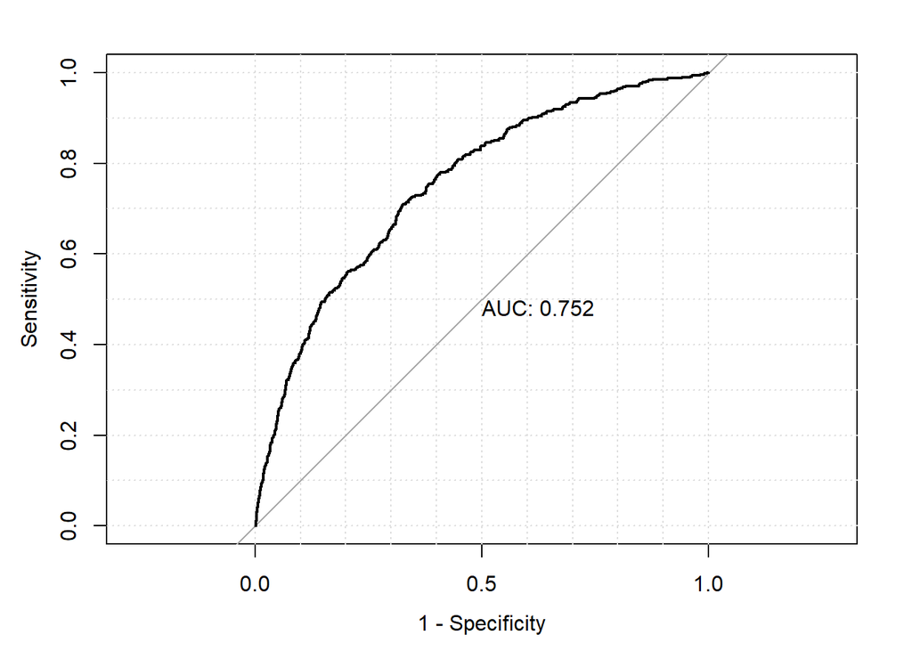

```r
plot(roc_obj, print.auc = TRUE, grid = TRUE, legacy.axes = TRUE, xlab = "1 - Specificity", ylab = "Sensitivity")
```

Segunda iteração: Grupo de variáveis “prediction_vars”

```r
# Fit
fit_logistic <- glm(formula, data = treinamento, family = binomial)
# Predição probabilidade de ser 1
depend_predict_logistic <- predict(fit_logistic, newdata = teste, type = "response")

# Convertendo probabilidade para binário:
depend_predict_bin <- ifelse(depend_predict_logistic > 0.5, "closed", "open")

# Calculando acurácia:
accuracy <- mean(depend_predict_bin == teste$fechado)
```

Calculando métricas de desempenho:

```r
# Create a ROC curve object
roc_obj <- roc(teste$fechado, depend_predict_logistic)
# Calculate AUC
auc_value <- auc(roc_obj)


# Calculate sensitivity and specificity
depend_predict_bin <- as.factor(depend_predict_bin)
teste$fechado <- as.factor(teste$fechado)

# Cria matrix de confusão
conf_matrix <- confusionMatrix(depend_predict_bin, teste$fechado)
sensitivity_value <- conf_matrix$byClass["Sensitivity"]
specificity_value <- conf_matrix$byClass["Specificity"]
```

Salvando resultados:

```r
# Salvando resultados:
resultados_logist$accuracy[resultados_logist$modelo == "segundo"] <- accuracy
resultados_logist$AUC[resultados_logist$modelo == "segundo"] <- auc_value
resultados_logist$sensitivity[resultados_logist$modelo == "segundo"] <- sensitivity_value
resultados_logist$specificity[resultados_logist$modelo == "segundo"] <- specificity_value
```

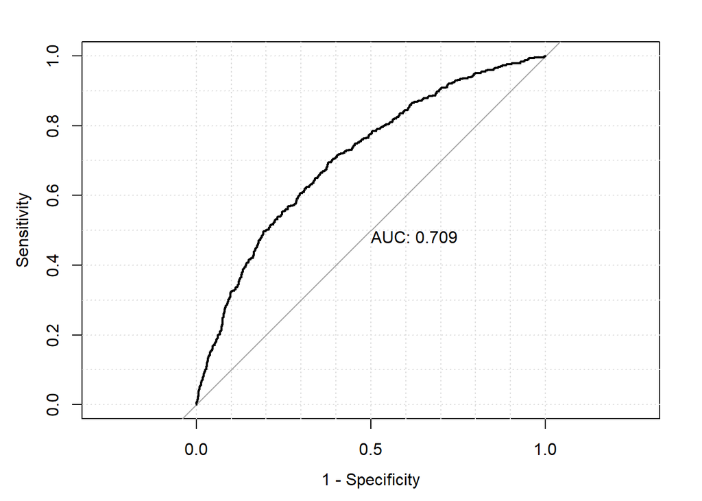

```r
plot(roc_obj, print.auc = TRUE, grid = TRUE, legacy.axes = TRUE, xlab = "1 - Specificity", ylab = "Sensitivity")
```

### Melhores resultados do modelo Logístico:

```r
resultados_logist
```

```
## # A tibble: 2 × 5
##   modelo   accuracy   AUC sensitivity specificity
##   <chr>       <dbl> <dbl>       <dbl>       <dbl>
## 1 primeiro    0.888 0.752       0.996     0.0321
## 2 segundo     0.888 0.709       0.998     0.00855
```

# Modelo 1 parte 2 - Electric boogalo

Vamos agora refazer as iterações do modelo logístico variando o híperparametro de corte para predição na probabilidade.

Primeira Iteração:

```r
# Fit
fit_logistic <- glm(fechado ~ ., data = treinamento, family = binomial)
# Predição probabilidade de ser 1
depend_predict_logistic <- predict(fit_logistic, newdata = teste, type = "response")
# Convertendo probabilidade para binário:
depend_predict_bin <- ifelse(depend_predict_logistic > 0.18, "closed", "open")

# Calculando acurácia:
accuracy <- mean(depend_predict_bin == teste$fechado)
```

Segunda iteração:

```r
# Fit
fit_logistic <- glm(formula, data = treinamento, family = binomial)
# Predição probabilidade de ser 1
depend_predict_logistic <- predict(fit_logistic, newdata = teste, type = "response")

# Convertendo probabilidade para binário:
depend_predict_bin <- ifelse(depend_predict_logistic > 0.18, "closed", "open")

# Calculando acurácia:
accuracy <- mean(depend_predict_bin == teste$fechado)
```

### Melhores resultados do modelo Logístico:

```r
resultados_logist
```

```
## # A tibble: 2 × 5
##   modelo   accuracy   AUC sensitivity specificity
##   <chr>       <dbl> <dbl>       <dbl>       <dbl>
## 1 primeiro    0.794 0.752       0.829       0.517
## 2 segundo     0.822 0.709       0.882       0.340
```

## Modelo 2

#### Encolhimento - LASSO

retiramos as variáveis não numéricas do modelo para simplificar a predição, escolhemos também o lasso para auxiliar no processo de seleção de variáveis.

```r
# Preparando para glmnet ------------------------------

columns_exclude <- c("gender", "origin", "region_m")
# Desconsideramos as variáveis não numéricas para o modelo

#desconsiderando variável dependente:

x <- as.matrix(treinamento[, -c(which(names(treinamento)=="fechado"), which(names(treinamento) %in% columns_exclude))])

y <- treinamento$fechado

x_test <- as.matrix(teste[, -c(which(names(teste)=="fechado"), which(names(teste) %in% columns_exclude))])
y_test <- teste$fechado

#definindo sequência de lambda
lambda_seq <- 10^seq(0, -4, length=100)
```

Primeiro fit, otimizando lambda com cross-validation:

```r
# LASSO com cross-validation para econtrar lambda ótimo:
fit_lasso_cv <- cv.glmnet(x, y, family = "binomial",
                          alpha = 1, lambda = lambda_seq)
lambda_best <- fit_lasso_cv$lambda.min
```

Predição com fit do modelo e lambda otimizado:

```r
# Predict probabilities for the test data
depend_predict_logistic_lasso <- predict(fit_lasso_cv, newx = x_test, s = lambda_best, type = "response")

# Convert probabilities to binary predictions
depend_predict_bin_lasso <- ifelse(depend_predict_logistic_lasso > 0.5, "closed", "open")

# Calculate accuracy
accuracy_lasso <- mean(depend_predict_bin_lasso == y_test)
```

Calculando métricas de desempenho:

```r
# Create a ROC curve object
roc_obj_lasso <- roc(y_test, depend_predict_logistic_lasso)
# Calculate AUC
auc_value_lasso <- auc(roc_obj_lasso)

# Ensure that the predicted values and true labels are factors with the same levels
depend_predict_bin_lasso <- as.factor(depend_predict_bin_lasso)
y_test <- as.factor(y_test)

# Create a confusion matrix
conf_matrix_lasso <- confusionMatrix(depend_predict_bin_lasso, y_test)
# Calculate sensitivity and specificity
sensitivity_value_lasso <- conf_matrix_lasso$byClass["Sensitivity"]
specificity_value_lasso <- conf_matrix_lasso$byClass["Specificity"]
```

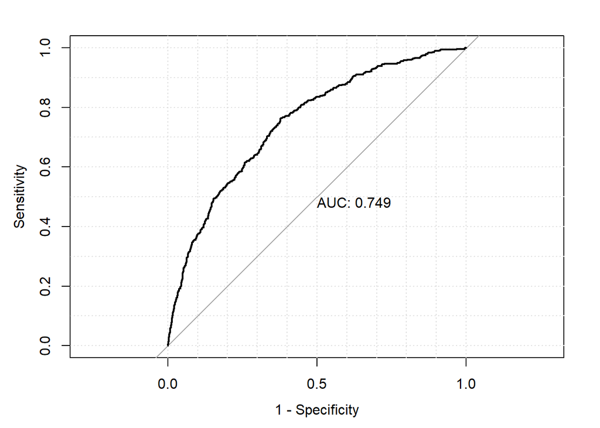

```r
plot(roc_obj_lasso, print.auc = TRUE, grid = TRUE, legacy.axes = TRUE, xlab = "1 - Specificity", ylab = "Sensitivity")
```

```r
cat("Accuracy:", accuracy_lasso, "\n")
```

```
## Accuracy: 0.8878549
```

```r
cat("AUC:", auc_value_lasso, "\n")
```

```
## AUC: 0.7492636
```

```r
cat("Sensitivity:", sensitivity_value_lasso, "\n")
```

```
## Sensitivity: 0.9970454
```

```r
cat("Specificity:", specificity_value_lasso, "\n")
```

```
## Specificity: 0.01923077
```

## Modelo 3

#### Random Forest

```r
# Fit do modelo Random Fortest utilizando todas as variáveis
(rf <- ranger(fechado ~ ., classification = TRUE, data = treinamento))
```

```
## Ranger result
##
## Call:
##  ranger(fechado ~ ., classification = TRUE, data = treinamento)
##
## Type:                             Classification
## Number of trees:                  500
## Sample size:                      16761
## Number of independent variables:  46
## Mtry:                             6
## Target node size:                 1
## Variable importance mode:         none
## Splitrule:                        gini
## OOB prediction error:             10.51 %
```

O erro da previsão do treinamento é de 11%.

```r
# matriz de confusão para as previsões no conjunto de treinamento
rf$confusion.matrix
```

```
##         predicted
## true      open closed
##   open   14759    131
##   closed  1631    240
```

A matriz de confusão é baseada nos dados OOB. As linhas da matriz indicam a categoria da resposta observada e as colunas indicam as categorias classificadas.

Avaliar hiperparâmetros

```r
# Avaliar combinação de mtry e número de árvores

tibble(arvores = seq(25, 500, 25))
```

```
## # A tibble: 20 × 1
##    arvores
##      <dbl>
##  1      25
##  2      50
##  3      75
##  4     100
##  5     125
##  6     150
##  7     175
##  8     200
##  9     225
## 10     250
## 11     275
## 12     300
## 13     325
## 14     350
## 15     375
## 16     400
## 17     425
## 18     450
## 19     475
## 20     500
```

```r
resultados_floresta <- crossing (mtry = c(4, 8),
                        n_arvores = c(1:15, seq(50, 500, 50)))

ajusta <- function(mtry, n_arvores) {

  rf <- ranger(fechado ~ ., num.trees = n_arvores, mtry = mtry, data = treinamento)

  return(rf$prediction.error)
}

resultados_floresta <- resultados_floresta %>%
  mutate(erro = map2_dbl(mtry, n_arvores, ajusta))

head(resultados_floresta)
```

```
## # A tibble: 6 × 3
##    mtry n_arvores  erro
##   <dbl>     <dbl> <dbl>
## 1     4         1 0.169
## 2     4         2 0.164
## 3     4         3 0.169
## 4     4         4 0.160
## 5     4         5 0.156
## 6     4         6 0.153
```

Vamos avaliar o menor erro obtido pelo modelo de otimização:

```r
resultados_floresta %>%
  arrange(erro)
```

```
## # A tibble: 50 × 3
##     mtry n_arvores  erro
##    <dbl>     <dbl> <dbl>
##  1     4       400 0.105
##  2     4       300 0.105
##  3     8       350 0.105
##  4     8       400 0.105
##  5     8       100 0.105
##  6     8       250 0.106
##  7     8       150 0.106
##  8     8       300 0.106
##  9     4       150 0.106
## 10     4       350 0.106
## # ℹ 40 more rows
```

Conforme observado na tabela acima, a combinação que diminui o erro do modelo é com mtry = 4 e o n_arvores = 400.

Este gráfico mostra como o erro de classificação OOB varia com diferentes números de árvores e para diferentes valores de mtry.

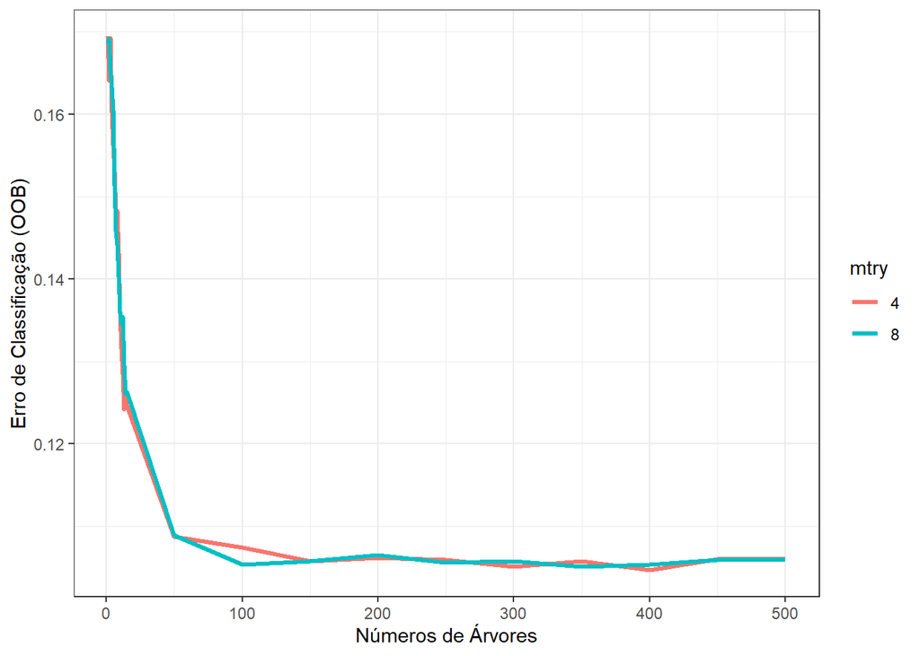

```r
resultados_floresta %>%
  mutate(mtry = factor(mtry)) %>%
  ggplot(aes(n_arvores, erro, group = mtry, color = mtry)) +
    geom_line(size = 1.2) +
    labs(x = "Números de Árvores", y = "Erro de Classificação (OOB)") +
    theme_bw()
```

Mostrar variáveis com maior grau de importância para o modelo:

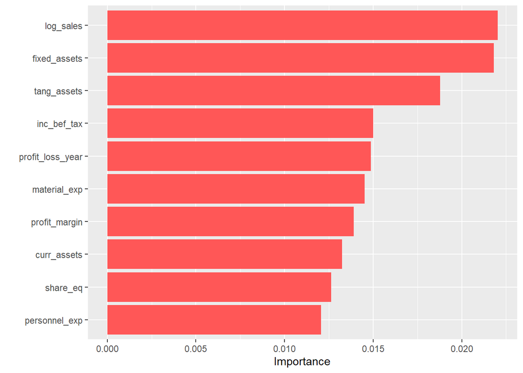

```r
# Importância

rf1 <- ranger(fechado ~ .-sales, importance = "permutation", data = treinamento)
vip::vip(rf1, aesthetics = list(fill = "#FF5757"))
```

```r
rf_prob <- ranger(fechado ~ ., mtry = 4, num.trees = 350, probability = TRUE, data = treinamento)

head(predict(rf_prob, teste, type="response")$predictions)
```

```
##           open     closed
## [1,] 1.0000000 0.00000000
## [2,] 0.9813934 0.01860658
## [3,] 0.8572415 0.14275850
## [4,] 0.9281893 0.07181066
## [5,] 0.9737506 0.02624943
## [6,] 0.9847540 0.01524603
```

```r
# Prever probabilidades
prob_fechado <- predict(rf_prob, teste, type = "response")$predictions[,2]

table(observado = teste$fechado,
      predito = ifelse(prob_fechado > .18, "closed", "open"))
```

```
##          predito
## observado closed open
##    open      675 3048
##    closed    309  159
```

```r
rf_prob$prediction.error
```

```
## [1] 0.08106743
```

Avaliando métricas de desempenho:

```r
roc_obj_rf <- roc(teste$fechado, prob_fechado)
desempenho <- coords(roc_obj_rf, 0.18, ret = c("1-accuracy", "sensitivity", "specificity", "ppv", "npv"))

auc_value_rf <- auc(roc_obj_rf)
```

```r
cat("Accuracy:", (1-desempenho$`1-accuracy`), "\n")
```

```
## Accuracy: 0.8010021
```

```r
cat("AUC:", auc_value_rf, "\n")
```

```
## AUC: 0.829812
```

```r
cat("Sensitivity:", desempenho$sensitivity, "\n")
```

```
## Sensitivity: 0.6602564
```

```r
cat("Specificity:", desempenho$specificity, "\n")
```

```
## Specificity: 0.8186946
```

## Modelo 4

#### Boosting:

- AdaBoosting

```r
# Fit an AdaBoost model
boost_model <- ada(fechado ~ ., data = treinamento)
```

Rodando modelo de predição:

```r
# Predict using the model on the test set
boost_pred <- predict(boost_model, newdata = teste)

# Extract predicted probabilities for class 1 from the AdaBoost model
boost_pred_prob <- predict(boost_model, newdata = teste, type = "prob")[, 2]

# Calculate accuracy
boost_accuracy <- mean(boost_pred == teste$fechado)
```

Calculando métricas de desempenho:

```r
# Create a ROC curve object
roc_obj_boost <- roc(teste$fechado, boost_pred_prob)
# Calculate AUC
auc_value_boost <- auc(roc_obj_boost)

# Create a confusion matrix
conf_matrix_boost <- confusionMatrix(boost_pred, teste$fechado)
# Calculate sensitivity and specificity
sensitivity_value_boost <- conf_matrix_boost$byClass["Sensitivity"]
specificity_value_boost <- conf_matrix_boost$byClass["Specificity"]
```

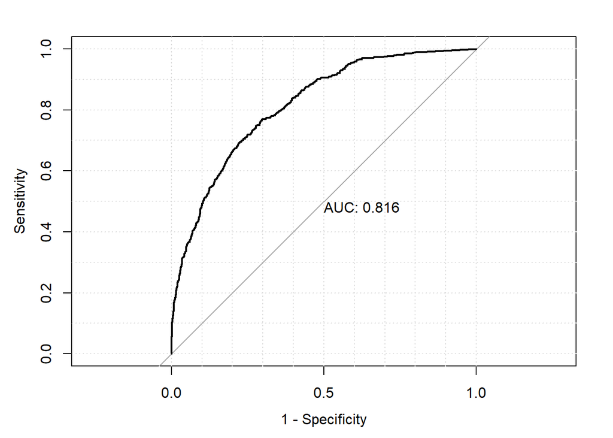

```r
plot(roc_obj_boost, print.auc = TRUE, grid = TRUE, legacy.axes = TRUE, xlab = "1 - Specificity", ylab = "Sensitivity")
```

```r
cat("Accuracy:", boost_accuracy, "\n")
```

```
## Accuracy: 0.8973992
```

```r
cat("AUC:", auc_value_boost, "\n")
```

```
## AUC: 0.815936
```

```r
cat("Sensitivity:", sensitivity_value_boost, "\n")
```

```
## Sensitivity: 0.9873758
```

```r
cat("Specificity:", specificity_value_boost, "\n")
```

```
## Specificity: 0.1816239
```

# Conferindo Resultados

```r
resultados
```

```
## # A tibble: 4 × 5
##   modelo        accuracy   AUC sensitivity specificity
##   <chr>            <dbl> <dbl>       <dbl>       <dbl>
## 1 Logistic         0.794 0.752       0.829      0.517
## 2 Shrinkage        0.888 0.749       0.997      0.0192
## 3 Random Forest    0.801 0.830       0.660      0.819
## 4 Boosting         0.897 0.816       0.987      0.182
```